# 머신러닝을 통한 채권 수익률 예측

# 2. Data and Methodology

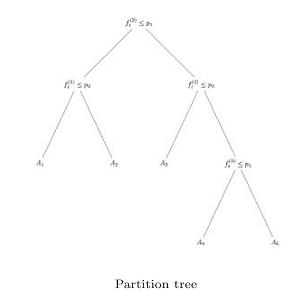

#### (c-1) 이자율 데이터 기반 Neural-Network 이자율 데이터 기반 NN은 1개의 레이어만 사용한다. 레이어의 수가 1개일 때 3개 또는 5개일 때보다 out-of-sample 성과가 좋게 나타난다 (Gu, Kelly and Xiu (2020) Bianchi, Buchner and Tamoni (2021)). 레이어의 수가 1개이기 때문에 레이어의 수가 많을 때보다 오버피팅의 줄어들고 out-of-sample 성과가 좋게 나타난다.

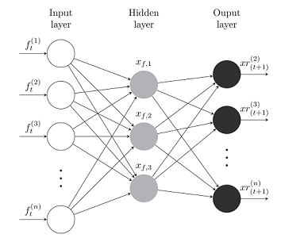

#### (c-2) 이자율 데이터 + 거시경제변수 기반 Neural-Network 거시경제변수를 추가로 활용하는 NN도 이자율 데이터만 활용하는 경우와 마찬가지로 1개의 레이어만 사용하여 학습한다. 단, 학습에 사용된 변수의 수가 늘어났기 때문에 노드의 수는 증가시킨다.

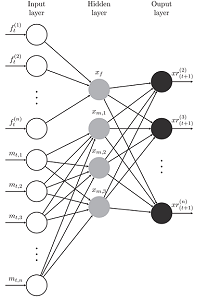

### 2.2.2 Sample Splitting Strategy

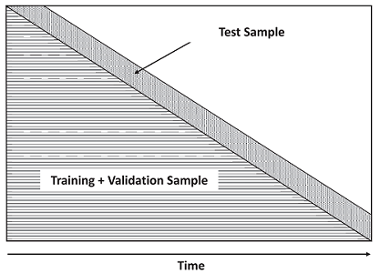

> 본 연구에서는 모델의 학습 데이터 기간을 60개월과 expanding 방식 두 가지로 나누어 진행했다. 60개월은 in-sample 데이터가 60개월 이상의 데이터가 있더라도 최근 60개월 데이터만 활용하여 모델을 학습시키는 방식이다. Expanding 방식은 모델의 in-sample 데이터를 모두 활용하여 모델을 학습시키는 방식이다. 일반적으로 in-sample 방식을 모두 사용하는 expanding 방식만 사용하지만 본 연구에서는 데이터 학습 기간에 따른 영향을 확인하기 위해 최근 60개월만 사용하는 방식을 추가하였다.

> 본 연구에서 사용하는 데이터는 시계열 데이터다. 따라서 시계열에 담긴 정보를 보존하기 위해 훈련 데이터와 검증 데이터를 랜덤하게 섞지 않는다. 훈련 데이터와 검증 데이터의 비율은 85%, 15%로 설정하였다. 최적 파라미터는 검증 데이터를 가장 잘 예측하는 파라미터로 설정하였다. 모델의 관점에서 학습하지 못한 테스트 데이터는 마지막 검증 데이터로부터 3개월이 지난 데이터를 활용하여 검증 데이터와 테스트 데이터가 겹치는 구간이 없도록 설정하였다.

### 2.2.3 Data Preprocessing 본 연구에서 사용하는 독립 변수 데이터(채권 이자율, 거시경제변수)는 모두 전처리를 한 후 모델 학습에 사용된다. Lasso 모형은 standard-scaling을, Extra tree 모형과 NN 모형은 min-max scaling을 사용한다. Scaler를 피팅할 때도 훈련 데이터와 검증 데이터만 사용하여 scaler를 피팅하였다. 테스트 데이터는 이미 피팅된 scaler를 사용하여 전처리 과정에서도 look-ahead bias가 발생하지 않도록 하였다.

# 3.1 Yield-only prediction result

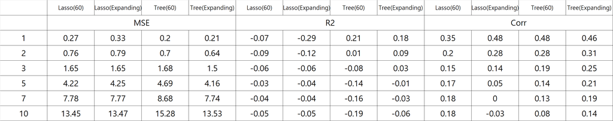

# Yield & Macro prediction result

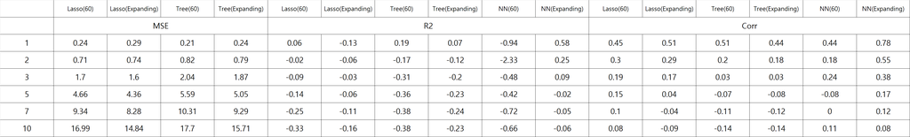

# Conclusion

> 시계열 데이터의 특성상 모델을 한번만 학습시키는 것이 아니라 훈련 데이터를 계속해서 늘려가면서 학습해야 하기 때문에 많은 컴퓨팅 파워가 필요하다. 따라서 추후에 컴퓨팅 파워가 보강되어 좀 더 모델을 수정한다면 본 연구보다 훨씬 우수한 성과를 보여줄 것이다.

## Code

```python
import time
from datetime import datetime

import matplotlib.pyplot as plt
import numpy as np
import pandas as pd
import tensorflow as tf
from fredapi import Fred
from keras import models, optimizers
from keras.callbacks import EarlyStopping, ModelCheckpoint
from keras.initializers.initializers_v2 import HeNormal
from keras.layers import Dense, BatchNormalization, Dropout, Input
from keras.layers.merge import concatenate
from keras.models import Model
from keras.regularizers import l1_l2
from keras.wrappers.scikit_learn import KerasRegressor
from sklearn.ensemble import ExtraTreesRegressor
from sklearn.linear_model import Lasso
from sklearn.metrics import mean_squared_error
from sklearn.metrics import r2_score
from sklearn.model_selection import GridSearchCV, PredefinedSplit
from sklearn.model_selection import ParameterGrid
from sklearn.model_selection import train_test_split
from sklearn.preprocessing import MinMaxScaler
from sklearn.preprocessing import StandardScaler

API_KEY = 'fc6eb7b311713a5d32db5ea8c16de695'  # Private API_KEY (Soo-Beom Ahn)

def get_after_release(data):
    pivot_data = data.pivot(index='date', columns='realtime_start', values='value').replace(['None', None], np.nan)
    pivot_data = pivot_data.resample('D', axis=1).last().ffill(axis=1)
    return pivot_data


def get_duration(y, m):  # y: yield, m: maturity
    z = 1 + y / 2
    return (1 / y) * (1 - z ** (-2 * m))


def get_convexity(y, m):  # y: yield, m: maturity
    z = 1 + y / 2
    return (2 / y ** 2) * (1 - z ** (-2 * m)) - (2 * m / y) * z ** -(2 * m + 1)


def get_total_return(y, m, freq='D'):  # y: yield, m: maturity
    delta_t_dict = {'D': 1 / 365, 'W': 1 / 52, 'M': 1 / 12, 'Y': 1}
    delta_t = delta_t_dict[freq]  # delta t in years
    y_r = y.resample(freq).last().ffill()  # yield resampled
    delta_yield = y_r.diff(1)

    yield_income = (1 + y_r) ** delta_t - 1
    duration = get_duration(y_r, m)
    convexity = get_convexity(y_r, m)
    total_return = yield_income - duration * delta_yield + 0.5 * convexity * delta_yield ** 2
    return total_return


def get_total_daily_return(y, m, freq='D'):  # y: yield, m: maturity
    delta_yield = y.diff(1)
    delta_t = (1 / 252)
    yield_income = (1 + y) ** delta_t - 1
    duration = get_duration(y, m)
    convexity = get_convexity(y, m)
    total_return = yield_income - duration * delta_yield + 0.5 * convexity * delta_yield ** 2
    return total_return


def build_nn(input, output, layer, node, seed, dropout, penalty, lr):
    initializer = HeNormal(seed=seed)
    np.random.seed(seed)
    tf.random.set_seed(seed)
    sgd = optimizers.gradient_descent_v2.SGD(nesterov=True, learning_rate=lr, momentum=0.9, decay=0.001)
    model = models.Sequential()
    model.add(Input(shape=input))
    model.add(Dropout(dropout))
    for i in range(layer):
        model.add(Dense(node, activation='relu', kernel_initializer=initializer, bias_initializer=initializer,
                        kernel_regularizer=l1_l2(penalty)))
    model.add(Dropout(dropout))
    model.add(BatchNormalization())
    model.add(Dense(output, kernel_initializer=initializer))
    model.compile(loss='mean_squared_error', optimizer=sgd)
    return model


def build_nn2(input1, input2, output, layer, node, seed, dropout, penalty, lr):
    initializer = HeNormal(seed=seed)
    np.random.seed(seed)
    tf.random.set_seed(seed)
    sgd = optimizers.gradient_descent_v2.SGD(nesterov=True, learning_rate=lr, momentum=0.9, decay=0.001)
    layers = dict()
    archi = np.repeat(node, layer)
    n = layer
    for i in range(n + 1):
        if i == 0:
            layers['ins_main'] = Input(shape=input1)
        elif i == 1:
            layers['dropout' + str(i)] = Dropout(dropout)(layers['ins_main'])
            layers['hidden' + str(i)] = Dense(archi[i - 1], kernel_regularizer=l1_l2(penalty),
                                              bias_initializer=initializer, kernel_initializer=initializer,
                                              activation='relu')(layers['dropout' + str(i)])
        elif i > 1 & i <= n:
            layers['dropout' + str(i)] = Dropout(dropout)(layers['hidden' + str(i - 1)])
            layers['hidden' + str(i)] = Dense(archi[i - 1], kernel_regularizer=l1_l2(penalty),
                                              bias_initializer=initializer, kernel_initializer=initializer,
                                              activation='relu')(layers['dropout' + str(i)])
    # Model for yield variables
    layers['ins_exog'] = Input(shape=input2)
    # Merge macro / yield networks
    layers['merge'] = concatenate([layers['hidden' + str(n)], layers['ins_exog']])
    layers['dropout_final'] = Dropout(dropout)(layers['merge'])
    layers['BN'] = BatchNormalization()(layers['dropout_final'])
    layers['output'] = Dense(output, bias_initializer='he_normal', kernel_initializer='he_normal')(layers['BN'])
    model = Model(inputs=[layers['ins_main'], layers['ins_exog']], outputs=layers['output'])
    model.compile(loss='mean_squared_error', optimizer=sgd)
    return model


class Bond:
    def __init__(self):
        self.fred = Fred(api_key=API_KEY)
        self.y10 = self.fred.get_series_first_release('DGS10') / 100.
        self.y7 = self.fred.get_series_first_release('DGS7') / 100.
        self.y5 = self.fred.get_series_first_release('DGS5') / 100.
        self.y3 = self.fred.get_series_first_release('DGS3') / 100.
        self.y2 = self.fred.get_series_first_release('DGS2') / 100.
        self.y1 = self.fred.get_series_first_release('DGS1') / 100.

        self.ff3_d = pd.read_csv("data/ff3_d.csv", index_col=0, parse_dates=[0]) / 100.
        self.ff3_d = np.log(1 + self.ff3_d)

        y10 = self.y10.copy().ffill()
        y7 = self.y7.copy().ffill()
        y5 = self.y5.copy().ffill()
        y3 = self.y3.copy().ffill()
        y2 = self.y2.copy().ffill()
        y1 = self.y1.copy().ffill()
        self.yield_df = pd.concat([y1, y2, y3, y5, y7, y10], axis=1).astype(float)
        self.yield_df.columns = ['1', '2', '3', '5', '7', '10']
```

```python
        self.log_yield_df = np.log(1 + self.yield_df)

        self.total_return_df = []
        for col in self.yield_df.columns:
            y = self.yield_df[col]
            total_return = get_total_daily_return(y=y, m=int(col))
            self.total_return_df.append(total_return)
        self.total_return_df = pd.concat(self.total_return_df, axis=1).astype(float)
        self.log_total_return_df = np.log(1 + self.total_return_df)

        self.forward_rate_df = [y1]
        for i in range(self.log_yield_df.shape[1] - 1):
            col0, col1 = self.log_yield_df.columns[i], self.log_yield_df.columns[i + 1]
            p0 = -1 * int(col0) * self.log_yield_df[col0]
            p1 = -1 * int(col1) * self.log_yield_df[col1]
            forward_rate = -p1 + p0
            self.forward_rate_df.append(forward_rate)
        self.forward_rate_df = pd.concat(self.forward_rate_df, axis=1).astype(float)
        self.forward_rate_df.columns = ['1', '2', '3', '5', '7', '10']

        self.macro = pd.read_csv("https://files.stlouisfed.org/files/htdocs/fred-md/monthly/current.csv", index_col=0,
                                 parse_dates=[0]).iloc[1:-1].shift(3)  # shift 3-month
        macro_index = [datetime.strptime(date, '%m/%d/%Y') for date in self.macro.index]
        self.macro.index = macro_index
        forward_index = self.forward_rate_df.resample('MS').first().index
        self.macro = self.macro.reindex(forward_index)
        self.macro = self.macro.resample('D').last().ffill().reindex(self.forward_rate_df.index)

    def get_forward_rate(self, n):
        p_0 = -(n - 1) * self.yield_m['%sm' % str(12 * (n - 1))]  # price of the n-1 maturity bond at t
        p_1 = -n * self.yield_m['%sm' % str(12 * n)]  # price of the n maturity at t
        return -p_1 + p_0

    def get_bond_risk_premium(self, n):
        p_0 = -(n - 1) * self.yield_m['%sm' % str(12 * (n - 1))]  # price of the n-1 maturity bond at t
        p_1 = -n * self.yield_m['%sm' % str(12 * n)].shift(12)  # price of the n maturity bond at t-1
        y_1 = np.log(1 + self.y1_m)
        return -p_1 + p_0 - y_1

    def get_linear_predict(self, X, y, period=63, rolling=60):
        y_all = y.rolling(period).sum()
        X_all = X.shift(period).dropna()

        date_list = [date for date in (set(X_all.index) & set(y_all.index))]
        date_list.sort()
        monthly_last = pd.DataFrame(index=date_list, data=date_list).resample('M').last().values
        monthly_last = [last[0] for last in monthly_last]
        real_lasso = pd.DataFrame(index=monthly_last, columns=y_all.columns)
        predict_lasso = pd.DataFrame(index=monthly_last, columns=y_all.columns)

        for last in monthly_last[120:]:
            index = date_list.index(last)
            if rolling == 'expanding':
                date_list2 = date_list[:index]
            else:
                last0 = monthly_last[monthly_last.index(last) - rolling]
                index0 = date_list.index(last0)
                date_list2 = date_list[index0:index]

            X = X_all.reindex(date_list2)
            y = y_all.reindex(date_list2)

            X_train, X_test, y_train, y_test = train_test_split(X.values, y.values, test_size=period, shuffle=False)
            scaler = StandardScaler()
            scaler.fit(X_train)
            X_train, X_test = scaler.transform(X_train), scaler.transform(X_test)

            params = {'alpha': np.linspace(0, 1, 1001)[1:]}

            N_train = int(np.round(np.size(X_train, axis=0) * 0.85))
            N_val = np.size(X_train, axis=0) - N_train
            test_fold = np.concatenate((np.full(N_train, -1), np.full(N_val, 0)))
            ps = PredefinedSplit(test_fold.tolist())

            lasso = GridSearchCV(estimator=Lasso(max_iter=int(1e6), tol=1e-6), cv=ps,
                                 param_grid=params, scoring='neg_mean_squared_error', n_jobs=-1)
            lasso.fit(X_train, y_train)
            print(last, lasso.best_params_)

            real_lasso.loc[last] = y_test[-1]
            predict_lasso.loc[last] = lasso.predict(X_test)[-1]

        real_lasso = real_lasso.dropna().astype(float)
        predict_lasso = predict_lasso.dropna().astype(float)

        return real_lasso, predict_lasso

    def get_nn_predict(self, X_input, y_input, period=63, rolling=60):
        print(period, time.strftime("%Y-%m-%d %H:%M:%S", time.localtime(time.time())))

        y_all = y_input.rolling(period).sum()
        X_all = X_input.shift(period).dropna()

        date_list = [date for date in (set(X_all.index) & set(y_all.index))]
        date_list.sort()
        monthly_last = pd.DataFrame(index=date_list, data=date_list).resample('M').last().values
        monthly_last = [last[0] for last in monthly_last]
        real_nn = pd.DataFrame(index=monthly_last, columns=y_all.columns)
        predict_nn = pd.DataFrame(index=monthly_last, columns=y_all.columns)

        for last in monthly_last[120:]:
            index = date_list.index(last)
            if rolling == 'expanding':
                date_list2 = date_list[:index]
            else:
                last0 = monthly_last[monthly_last.index(last) - rolling]
                index0 = date_list.index(last0)
                date_list2 = date_list[index0:index]

            X = X_all.reindex(date_list2)
            y = y_all.reindex(date_list2)

            X_train, X_test, y_train, y_test = train_test_split(X.values, y.values, test_size=period, shuffle=False)
            scaler = MinMaxScaler((-1, 1))
            scaler.fit(X_train)
            X_train, X_test = scaler.transform(X_train), scaler.transform(X_test)

            model = KerasRegressor(build_fn=build_nn)
            params = {'input': [X_train.shape[1]],
                      'output': [y_train.shape[1]],
                      'layer': [1],
                      'node': [3, 5, 7],
                      'seed': [n for n in range(100, 101)],
                      'dropout': [0.0, 0.3],
                      'penalty': [1e-3, 1e-4],
                      'batch_size': [32],
                      'lr': [1e-3, 1e-2]}
```

```python
            N_train = int(np.round(np.size(X_train, axis=0) * 0.85))
            N_val = np.size(X_train, axis=0) - N_train
            test_fold = np.concatenate((np.full(N_train, -1), np.full(N_val, 0)))
            ps = PredefinedSplit(test_fold.tolist())

            earlystopping = EarlyStopping(monitor='loss', min_delta=1e-6, patience=20, mode='auto', verbose=0)
            nn_gs = GridSearchCV(estimator=model, param_grid=params, cv=ps, n_jobs=6, verbose=0,
                                 scoring='neg_mean_squared_error')
            nn_gs.fit(X_train, y_train, epochs=500, verbose=0, callbacks=[earlystopping])

            print(nn_gs.best_params_)
            try:
                predict_nn.loc[last] = nn_gs.predict(X_test)
                real_nn.loc[last] = y_test
                print(last, nn_gs.predict(X_test), y_test)
            except:
                predict_nn.loc[last] = nn_gs.predict(X_test)[-1]
                real_nn.loc[last] = y_test[-1]
                print(last, nn_gs.predict(X_test)[-1], y_test[-1])
            print(nn_gs.score(X_train, y_train))

        real_nn = real_nn.dropna().astype(float)
        predict_nn = predict_nn.dropna().astype(float)

        print(mean_squared_error(real_nn, predict_nn))

        return real_nn, predict_nn

    def get_nn_predict2(self, X_input, y_input, period=63, rolling=60):
        print(period, time.strftime("%Y-%m-%d %H:%M:%S", time.localtime(time.time())))
        seed, layer, node, input1, input2, output, dropout, penalty, lr = 100, 1, 32, 127, 6, 6, 0.3, 1e-4, 1e-4

        X_all = X_input.shift(period).dropna()
        y_all = y_input.rolling(period).sum()

        date_list = [date for date in (set(X_all.index) & set(y_all.index))]
        date_list.sort()
        monthly_last = pd.DataFrame(index=date_list, data=date_list).resample('M').last().values
        monthly_last = [last[0] for last in monthly_last]
        real_nn = pd.DataFrame(index=monthly_last, columns=y_all.columns)
        predict_nn = pd.DataFrame(index=monthly_last, columns=y_all.columns)

        for last in monthly_last[120:]:
            index = date_list.index(last)
            if rolling == 'expanding':
                date_list2 = date_list[:index]
            else:
                last0 = monthly_last[monthly_last.index(last) - rolling]
                index0 = date_list.index(last0)
                date_list2 = date_list[index0:index]

            X = X_all.reindex(date_list2)
            y = y_all.reindex(date_list2)[['10']]

            X_train, X_test, y_train, y_test = train_test_split(X.values, y.values, test_size=period, shuffle=False)
            scaler = MinMaxScaler((-1, 1))
            scaler.fit(X_train)
            X_train, X_test = scaler.transform(X_train), scaler.transform(X_test)
            macro = self.macro.shape[1]

            #  X1: macro, X2: forward
            X1_train, X2_train, X1_test, X2_test = X_train[:, :macro], X_train[:, macro:], X_test[:, :macro], X_test[:,
                                                                                                              macro:]

            initializer = HeNormal(seed=seed)
            np.random.seed(seed)
            tf.random.set_seed(seed)
            sgd = optimizers.gradient_descent_v2.SGD(nesterov=True, learning_rate=lr, momentum=0.9, decay=0.001)
            layers = dict()
            archi = [32]
            n = len(archi)
            for i in range(n + 1):
                if i == 0:
                    layers['ins_main'] = Input(shape=input1)
                elif i == 1:
                    layers['dropout' + str(i)] = Dropout(dropout)(layers['ins_main'])
                    layers['hidden' + str(i)] = Dense(archi[i - 1], kernel_regularizer=l1_l2(penalty),
                                                      bias_initializer=initializer, kernel_initializer=initializer,
                                                      activation='relu')(layers['dropout' + str(i)])
                elif i > 1 & i <= n:
                    layers['dropout' + str(i)] = Dropout(dropout)(layers['hidden' + str(i - 1)])
                    layers['hidden' + str(i)] = Dense(archi[i - 1], kernel_regularizer=l1_l2(penalty),
                                                      bias_initializer=initializer, kernel_initializer=initializer,
                                                      activation='relu')(layers['dropout' + str(i)])
            # Model for yield variables
            layers['ins_exog'] = Input(shape=input2)
            # Merge macro / yield networks
            layers['merge'] = concatenate([layers['hidden' + str(n)], layers['ins_exog']])
            layers['dropout_final'] = Dropout(dropout)(layers['merge'])
            layers['BN'] = BatchNormalization()(layers['dropout_final'])
            layers['output'] = Dense(output, bias_initializer='he_normal', kernel_initializer='he_normal')(layers['BN'])
            nn_gs = Model(inputs=[layers['ins_main'], layers['ins_exog']], outputs=layers['output'])
            nn_gs.compile(loss='mean_squared_error', optimizer=sgd)

            earlystopping = EarlyStopping(monitor='loss', min_delta=1e-6, patience=20, mode='auto', verbose=0)
            nn_gs.fit([X1_train, X2_train], y_train, epochs=500, callbacks=[earlystopping], verbose=0, workers=6)

            predict_nn.loc[last] = nn_gs.predict([X1_test, X2_test])[-1]
            real_nn.loc[last] = y_test[-1]
            print(last, nn_gs.predict([X1_test, X2_test])[-1], y_test[-1])

        real_nn = real_nn.dropna().astype(float)
        predict_nn = predict_nn.dropna().astype(float)

        print(mean_squared_error(real_nn, predict_nn))

        for year in ['1', '2', '3', '5', '7', '10']:
            print(r2_score(real_nn[year], predict_nn[year]))
            print(np.corrcoef(real_nn[year], predict_nn[year]))

        return real_nn, predict_nn

    def get_rf_predict(self, X, y, period=63, rolling=60):
        print(time.strftime("%Y-%m-%d %H:%M:%S", time.localtime(time.time())))
```

```python
        y_all = y.rolling(period).sum()
        X_all = X.shift(period).dropna()

        date_list = [date for date in (set(X_all.index) & set(y_all.index))]
        date_list.sort()
        monthly_last = pd.DataFrame(index=date_list, data=date_list).resample('M').last().values
        monthly_last = [last[0] for last in monthly_last]
        real_tree = pd.DataFrame(index=monthly_last, columns=y_all.columns)
        predict_tree = pd.DataFrame(index=monthly_last, columns=y_all.columns)

        for last in monthly_last[120:]:
            index = date_list.index(last)
            if rolling == 'expanding':
                date_list2 = date_list[:index]
            else:
                last0 = monthly_last[monthly_last.index(last) - rolling]
                index0 = date_list.index(last0)
                date_list2 = date_list[index0:index]

            X = X_all.reindex(date_list2)
            y = y_all.reindex(date_list2)

            X_train, X_test, y_train, y_test = train_test_split(X.values, y.values, test_size=period, shuffle=False)
            scaler = MinMaxScaler((-1, 1))
            scaler.fit(X_train)
            X_train, X_test = scaler.transform(X_train), scaler.transform(X_test)

            et = ExtraTreesRegressor()

            params = {
                'bootstrap': [True],
                'n_estimators': [100],
                'max_depth': [2, 5, 10],
                'random_state': [n for n in range(100, 101)],
                'min_samples_leaf': [2, 4, 8]
            }

            N_train = int(np.round(np.size(X_train, axis=0) * 0.85))
            N_val = np.size(X_train, axis=0) - N_train
            test_fold = np.concatenate((np.full(N_train, -1), np.full(N_val, 0)))
            ps = PredefinedSplit(test_fold.tolist())

            regressor = GridSearchCV(estimator=et, scoring='neg_mean_squared_error', param_grid=params, verbose=1,
                                     cv=ps, n_jobs=-1)
            regressor.fit(X_train, y_train)
            print(last, regressor.best_params_)

            real_tree.loc[last] = y_test[-1]
            predict_tree.loc[last] = regressor.predict(X_test)[-1]
            print(regressor.predict(X_test)[-1], y_test[-1])
            print(regressor.score(X_train, y_train))
        real_tree = real_tree.dropna().astype(float)
        predict_tree = predict_tree.dropna().astype(float)

        return real_tree, predict_tree


if __name__ == '__main__':
    self = Bond()
    X_input1 = self.forward_rate_df.astype(float).loc['1992-05-01':'2021-11-30']
    X_input2 = pd.concat([self.macro, self.forward_rate_df], axis=1).astype(float).loc['1992-05-01':'2021-11-30']
    y_input = self.log_total_return_df
```